# EV

User

4/28/2023

1.Multiple scatterplots (or boxplots) for a categorical variable using the for loop, and export them as jpeg files:

```r
library(ggplot2)

# Assuming the categorical variable is "category"
unique_categories <- unique(data$category)

for (category in unique_categories) {
  plot_data <- data[data$category == category, ]
  plot <- ggplot(plot_data, aes(x = parameter, y = value)) +
    geom_point() +
    ggtitle(paste("Category:", category)) +
    xlab("Parameter") + ylab("Value")
  ggsave(paste("plot_", category, ".jpeg", sep = ""), plot, device = "jpeg")
}
# Define variables
categorical_var <- "region"
plot_var <- "value"

# Create for loop to generate plots for each level of the categorical variable
for(i in unique(data[[categorical_var]])) {
  plot_data <- data %>% filter(.data[[categorical_var]] == i)
  jpeg(filename = paste0(i,".jpeg"), width = 800, height = 600)
  plot <- ggplot(plot_data, aes_string(x = plot_var)) + geom_boxplot() + ggtitle(i)
  print(plot)
  dev.off()
}

plot_data
```

```
## # A tibble: 763 × 8
##    region category   parameter      mode   powertrain  year unit          value
##    <chr>  <chr>      <chr>          <chr>  <chr>      <dbl> <chr>         <dbl>
##  1 World  Historical EV stock share Cars   EV          2010 percent    0.00190
##  2 World  Historical EV stock share Trucks EV          2010 percent    0.000700
##  3 World  Historical EV sales share Vans   EV          2010 percent    0.0270
##  4 World  Historical EV stock share Vans   EV          2010 percent    0.00440
##  5 World  Historical EV sales share Cars   EV          2010 percent    0.0120
##  6 World  Historical EV sales       Trucks BEV         2010 sales     21
##  7 World  Historical EV sales       Vans   BEV         2010 sales   1600
##  8 World  Historical EV sales       Cars   BEV         2010 sales   7400
##  9 World  Historical EV sales       Cars   PHEV        2010 sales    380
## 10 World  Historical EV stock       Buses  BEV         2010 stock   2100
## # … with 753 more rows
```

```r
# load required packages
library(ggplot2)

# create a list of unique categories in the 'category' column
cat_list <- unique(data$category)

# create a for loop to create scatterplots or boxplots for each category
for (cat in cat_list) {
  # filter data for a specific category
  cat_data <- data[data$category == cat, ]

  # create scatterplot or boxplot depending on the parameter
  if (cat_data$parameter[1] == "CO2 emissions") {
    plot <- ggplot(cat_data, aes(x = year, y = value, color = mode)) +
      geom_point(aes(size = powertrain), alpha = 0.7) +
      ggtitle(paste0(cat, " ", cat_data$parameter[1])) +
      theme_bw()
  } else {
    plot <- ggplot(cat_data, aes(x = mode, y = value, fill = powertrain)) +
      geom_boxplot() +
      ggtitle(paste0(cat, " ", cat_data$parameter[1])) +
      theme_bw()
  }

  # save plot as jpeg file
  ggsave(paste0(cat, "_", cat_data$parameter[1], ".jpeg"), plot)
}
```

2. Different types of plots, including scatterplots, boxplots (try to change x axis names and rotate the names to a certain angle), barplots (ideally with standard deviation bar), and pie charts:

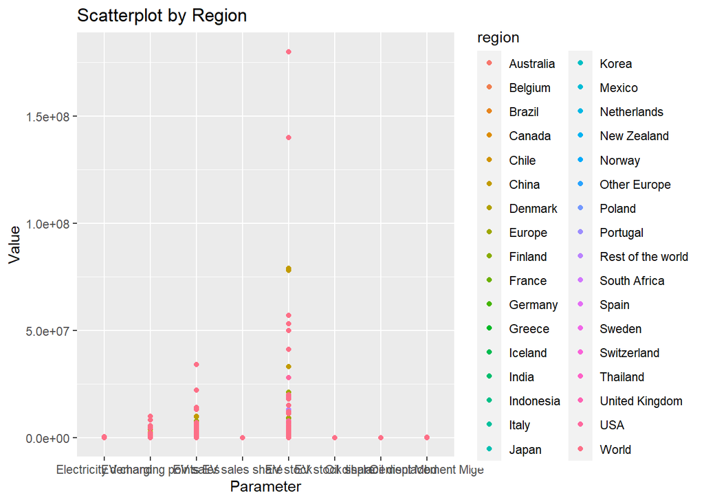

```r
library(ggplot2)

# Scatterplot
ggplot(data, aes(x = parameter, y = value, color = region)) +
  geom_point() +
  xlab("Parameter") + ylab("Value") +
  ggtitle("Scatterplot by Region")
```

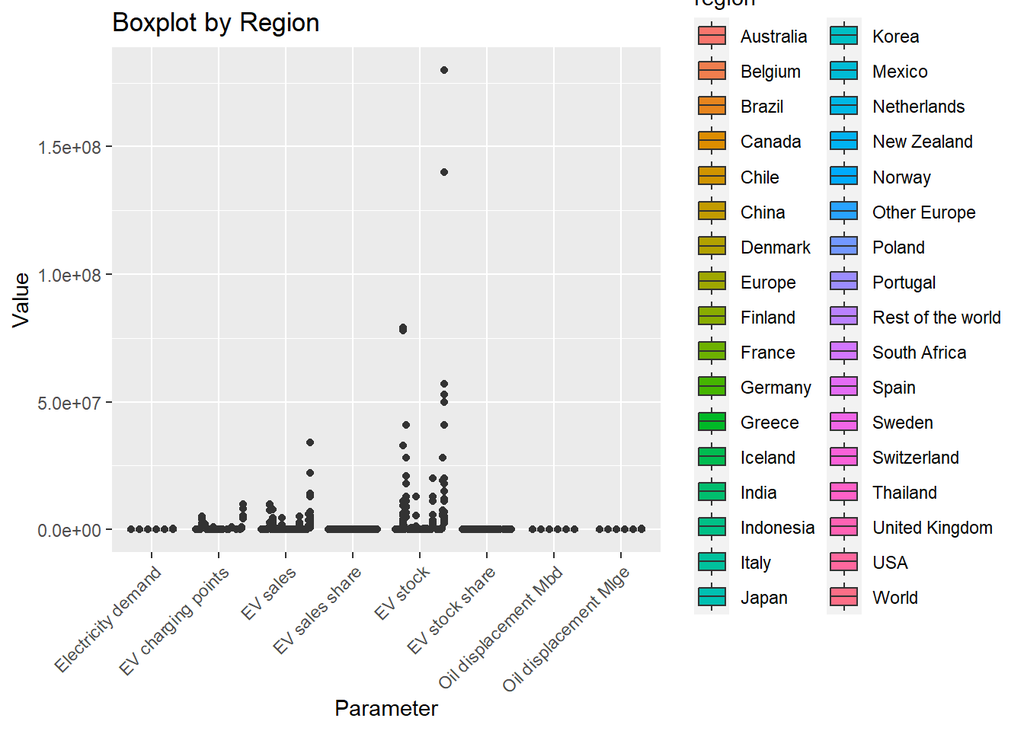

```r
# Boxplot with rotated x-axis labels
ggplot(data, aes(x = parameter, y = value, fill = region)) +
  geom_boxplot() +
  theme(axis.text.x = element_text(angle = 45, hjust = 1)) +
  xlab("Parameter") + ylab("Value") +
  ggtitle("Boxplot by Region")
```

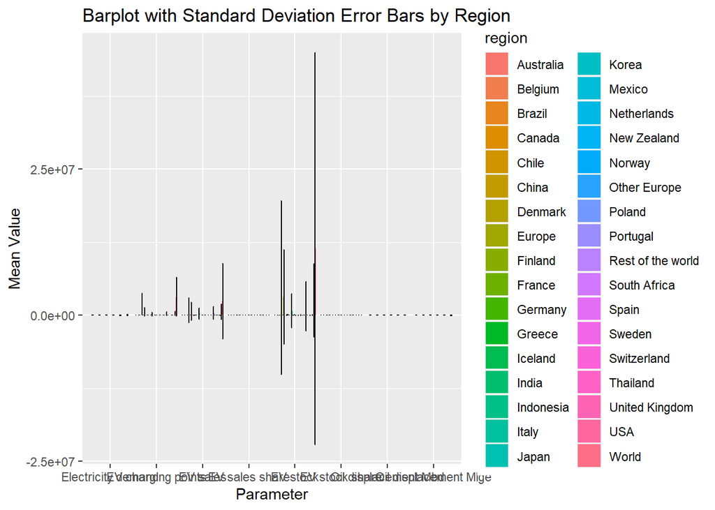

```r
# Barplot with standard deviation error bars
library(dplyr)
data_summary <- data %>%
  group_by(region, category, parameter) %>%
  summarize(mean_value = mean(value), sd_value = sd(value))
ggplot(data_summary, aes(x = parameter, y = mean_value, fill = region)) +
  geom_bar(stat = "identity", position = position_dodge()) +
  geom_errorbar(aes(ymin = mean_value - sd_value, ymax = mean_value + sd_value),
                position = position_dodge(0.9), width = 0.25) +
  xlab("Parameter") + ylab("Mean Value") +
  ggtitle("Barplot with Standard Deviation Error Bars by Region")
```

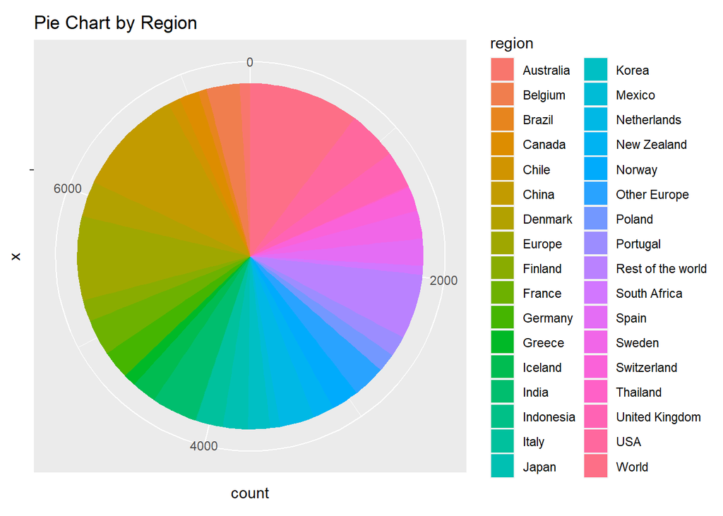

```r
# Pie chart
library(tidyr)
data_summary2 <- data %>%
  group_by(region) %>%
  summarize(count = n())

ggplot(data_summary2, aes(x = "", y = count, fill = region)) +
  geom_bar(stat = "identity", width = 1) +
  coord_polar("y", start = 0) +
  ggtitle("Pie Chart by Region")
```

3. High-dimension plots using the lattice package, and practice using the tidyr and dplyr packages to do variable selection and wide-to-long table conversion, if your dataset allows to do the conversion:

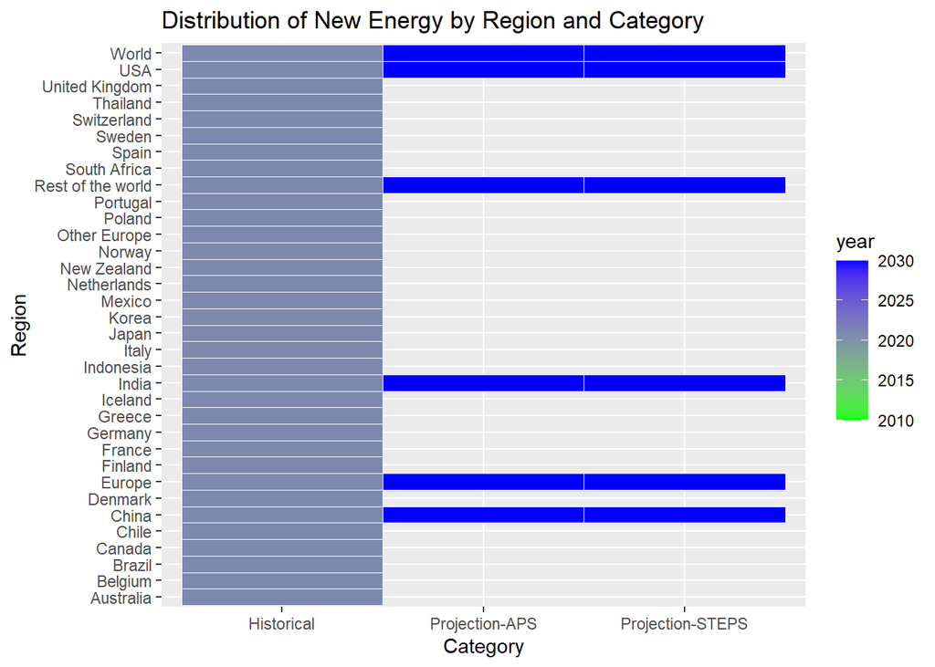

```r
library(ggplot2)

# Convert data to wide format
data_wide <- data %>%
  pivot_wider(names_from = "parameter", values_from = "value")

# Create heatmap using ggplot2
ggplot(data_wide, aes(x = category, y = region, fill = year)) +
  geom_tile(color = "white") +
  scale_fill_gradient(low = "green", high = "blue") +
  labs(x = "Category", y = "Region", title = "Distribution of New Energy by Region and Category")
```

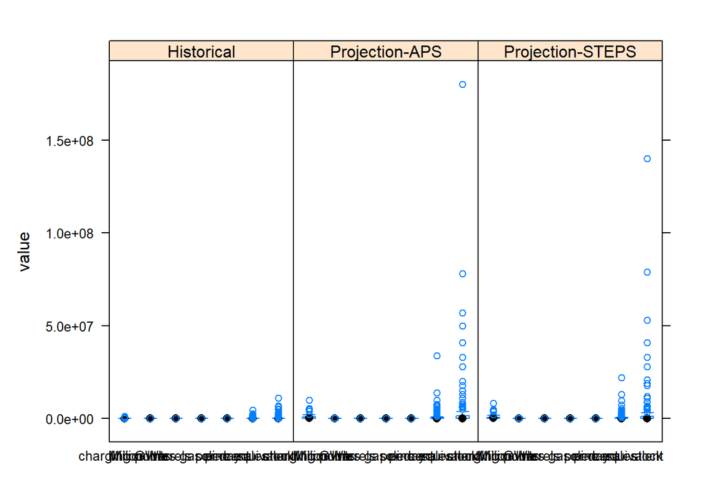

```r
library(lattice)
library(dplyr)

mydata_select <- data %>%
  dplyr::select(category, parameter, mode, powertrain, year, unit, value)

mydata_long <- mydata_select %>%
  gather(key = "variable", value = "value", -category, -parameter, -mode, -powertrain, -year, -unit, -value)

bwplot(value ~ unit | category, data = mydata_long)
```

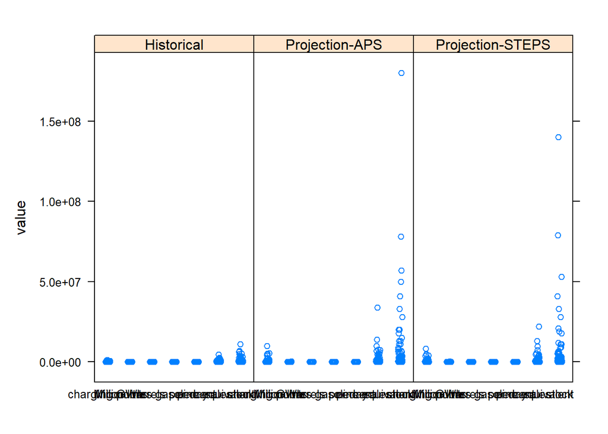

```r
stripplot(value ~ unit | category, data = mydata_long, jitter.data = TRUE)
```

4. applying the qplot() function in ggplot2 to generate scatterplot, boxplot, histogram, line plot, etc. Try to vary color, shape, and size, whenever possible.

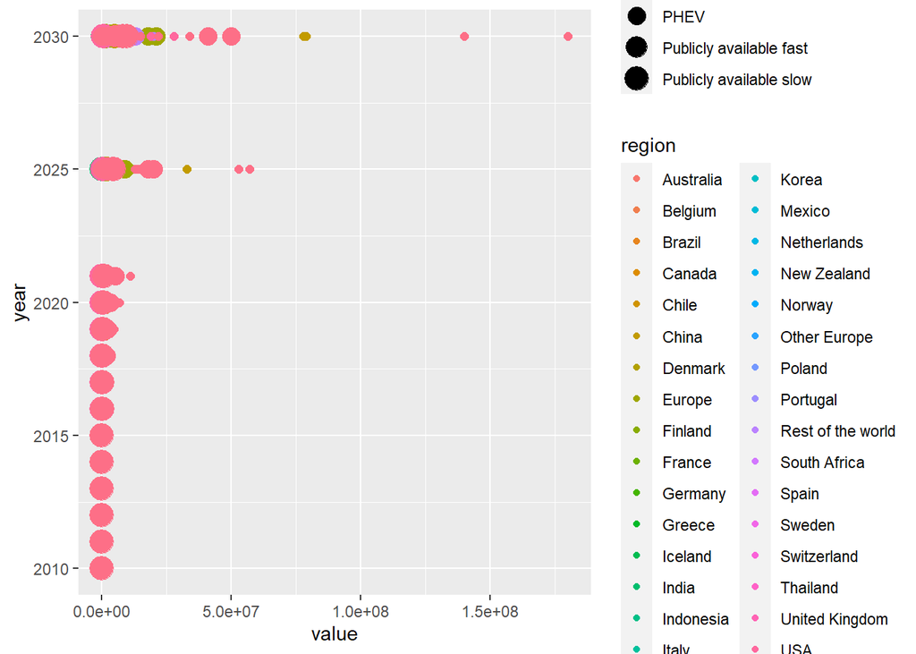

```r
# Scatterplot
qplot(x = value, y = year, data = data, color = region, size = powertrain)
```

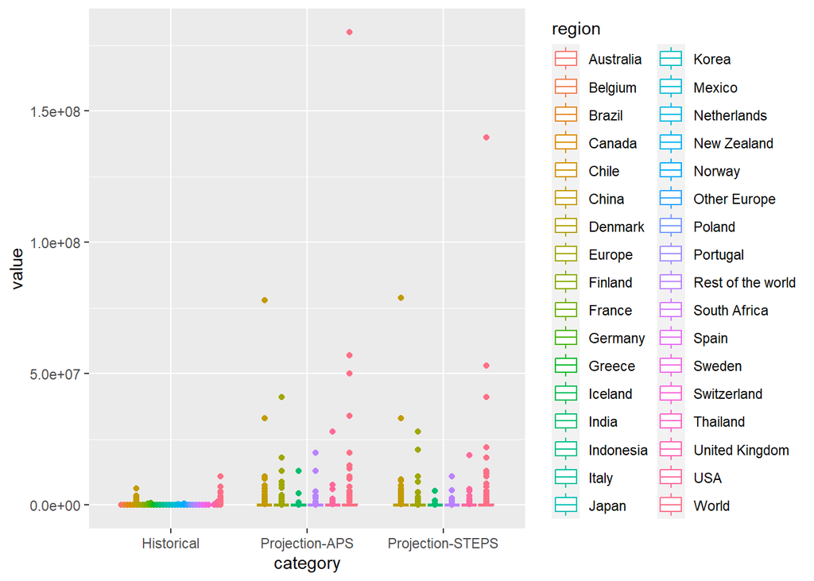

```r
# Boxplot
qplot(x = category, y = value, data = data, geom = "boxplot", color = region)
```

[figure not shown]

```r
# Histogram
qplot(x = value, data = data, fill = region, alpha = I(0.5), binwidth = 5)
```

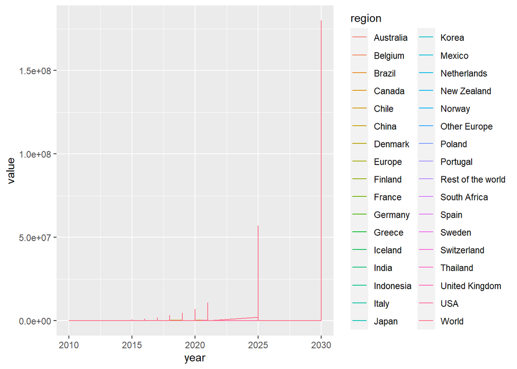

```r
# Line plot
qplot(x = year, y = value, data = data, group = region, color = region, geom = "line")
```

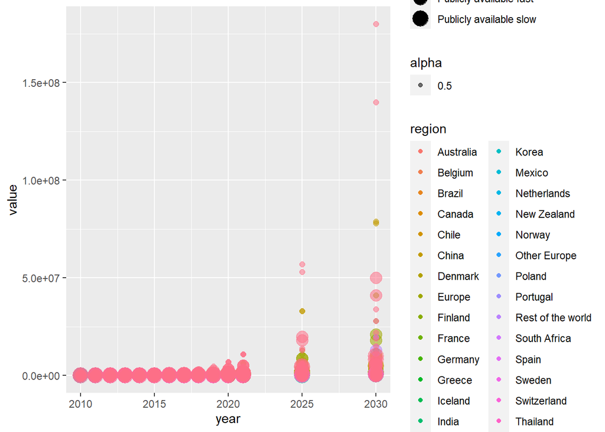

```r
library(ggplot2)

qplot(year, value, data = data, color = region, size = powertrain, alpha = 0.5)
```

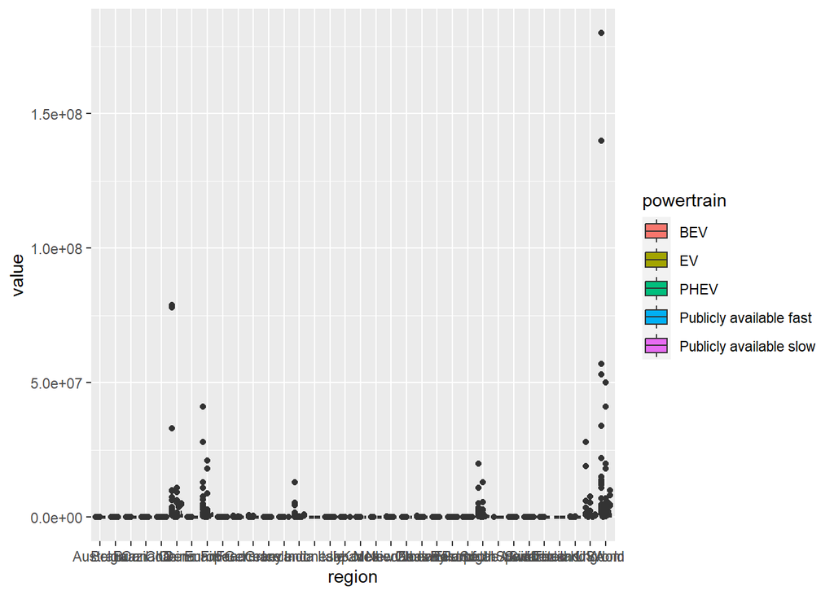

```r
qplot(region, value, data = data, geom = "boxplot", fill = powertrain)
```

[figure not shown]

```r
qplot(value, data = data, geom = "histogram", binwidth = 100, fill = powertrain, alpha = 0.5)
```

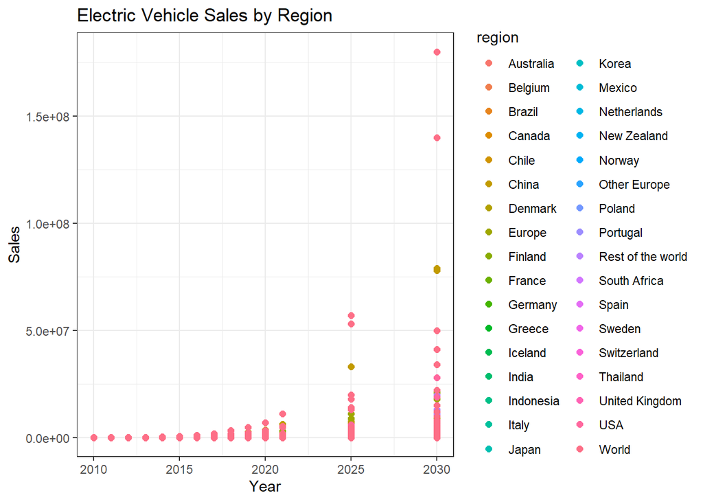

```r
library(ggplot2)

# Scatterplot
ggplot(data = data, aes(x = year, y = value, color = region)) +
  geom_point(size = 2) +
  ggtitle("Electric Vehicle Sales by Region") +
  xlab("Year") +
  ylab("Sales") +
  theme_bw()
```

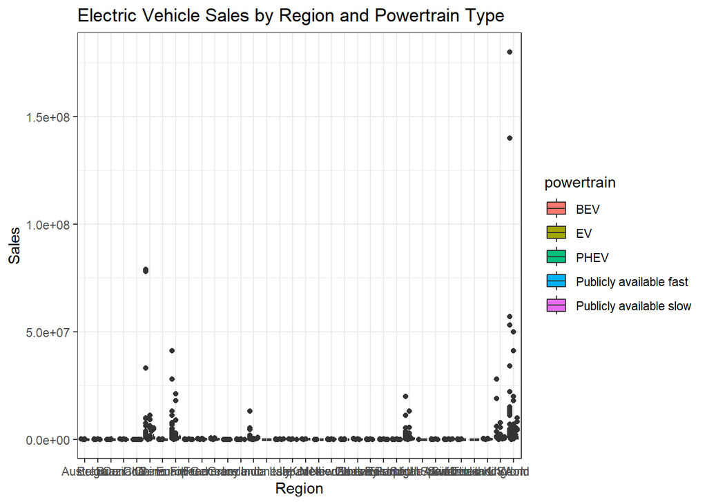

```r
# Boxplot
ggplot(data = data, aes(x = region, y = value, fill = powertrain)) +
  geom_boxplot() +
  ggtitle("Electric Vehicle Sales by Region and Powertrain Type") +
  xlab("Region") +
  ylab("Sales") +
  theme_bw()
```

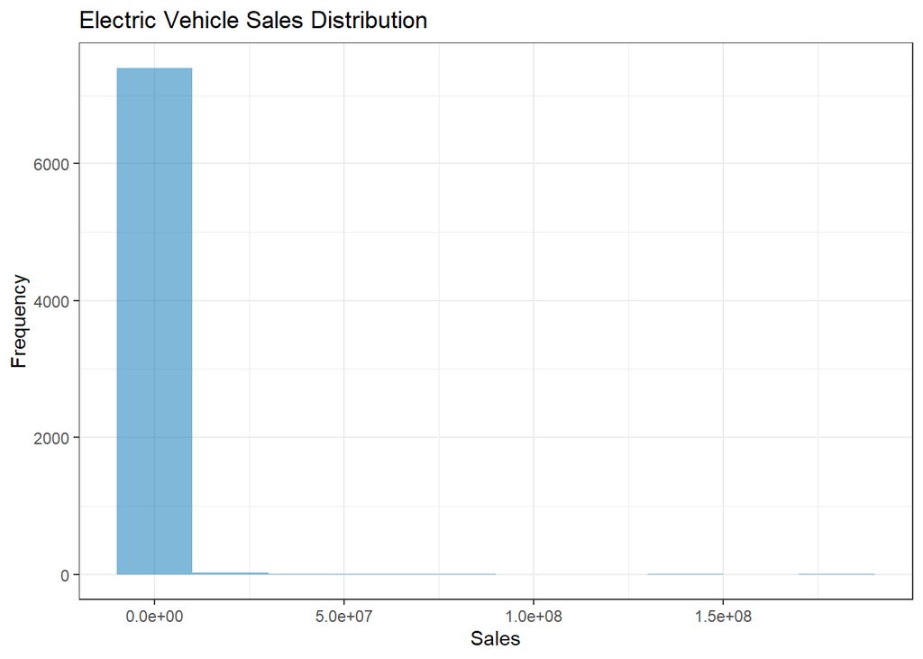

```r
# Histogram
ggplot(data = data, aes(x = value)) +
  geom_histogram(bins = 10, fill = "#0072B2", alpha = 0.5) +
  ggtitle("Electric Vehicle Sales Distribution") +
  xlab("Sales") +
  ylab("Frequency") +
  theme_bw()
```

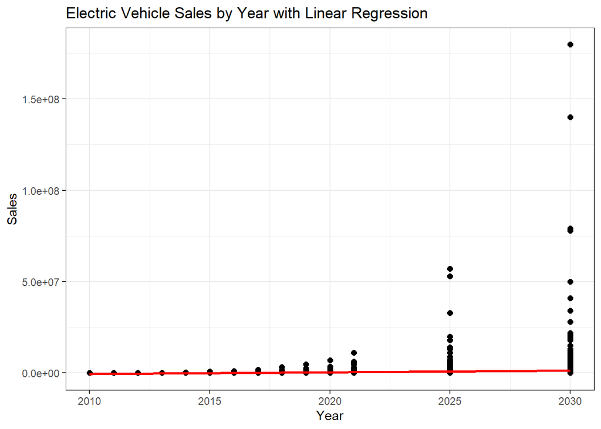

```r
# Linear regression and residual plot
ggplot(data = data, aes(x = year, y = value)) +
  geom_point(size = 2) +
  ggtitle("Electric Vehicle Sales by Year") +
  xlab("Year") +
  ylab("Sales") +
  theme_bw() +
  geom_smooth(method = "lm", se = FALSE, color = "red") +
  ggtitle("Electric Vehicle Sales by Year with Linear Regression") +
  xlab("Year") +
  ylab("Sales") +
  theme_bw()
```

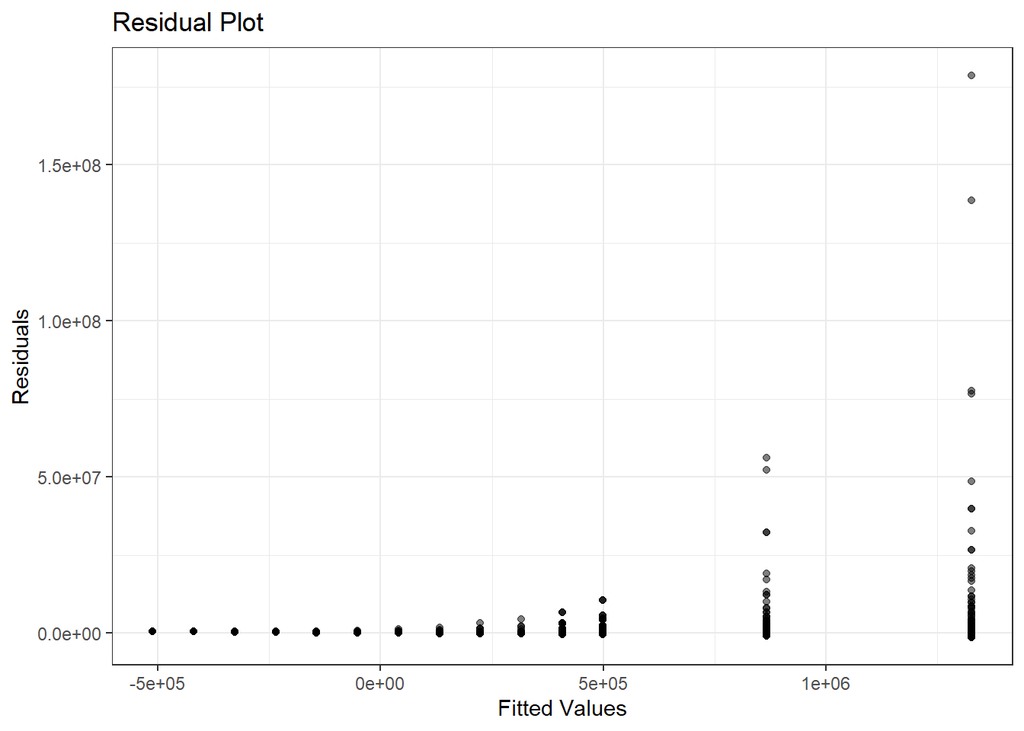

```r
# Residual plot
model <- lm(value ~ year, data = data)
ggplot(data = data, aes(x = fitted(model), y = resid(model))) +
  geom_point(alpha = 0.5) +
  ggtitle("Residual Plot") +
  xlab("Fitted Values") +
  ylab("Residuals") +
  theme_bw()
```

6. different strategies to visualize distributions in 1d and 2d (as a way to deal with overplotting). Try to vary the transparency level and use the jitter() function to reduce overplotting.

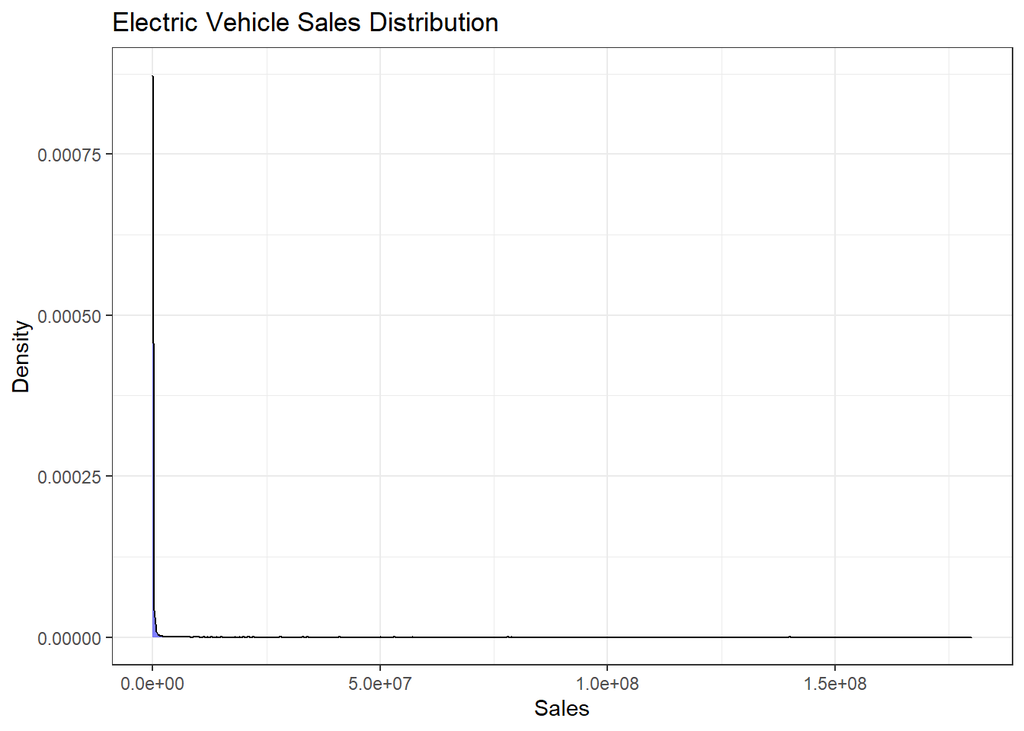

```r
# 1D density plot with transparency
ggplot(data = data, aes(x = value)) +
  geom_density(alpha = 0.5, fill = "blue") +
  ggtitle("Electric Vehicle Sales Distribution") +
  xlab("Sales") +
  ylab("Density") +
  theme_bw()
```

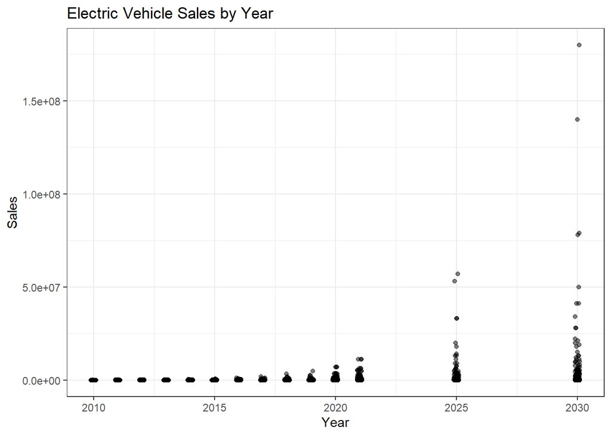

```r
# 2D scatterplot with jitter and transparency
ggplot(data = data, aes(x = year, y = value)) +
  geom_jitter(width = 0.1, height = 0, alpha = 0.5) +
  ggtitle("Electric Vehicle Sales by Year") +
  xlab("Year") +
  ylab("Sales") +
  theme_bw()
```

7. Changing color scales, faceting, and creating contingency table with chi-square test of independence:

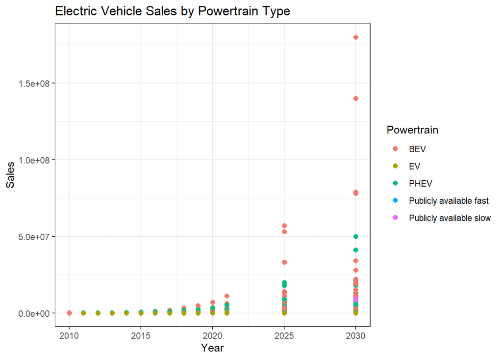

```r
# Discrete color scale
ggplot(data = data, aes(x = year, y = value, color = powertrain)) +
  geom_point(size = 2) +
  ggtitle("Electric Vehicle Sales by Powertrain Type") +
  xlab("Year") +
  ylab("Sales") +
  scale_color_discrete(name = "Powertrain") +
  theme_bw()
```

```r
# Create a contingency table
cont_table <- table(data$region, data$category)
cont_table
```

```
##
##                     Historical Projection-APS Projection-STEPS
##   Australia                 74              0                0
##   Belgium                  229              0                0
##   Brazil                    60              0                0
##   Canada                   137              0                0
##   Chile                     82              0                0
##   China                    417            167              167
##   Denmark                  247              0                0
##   Europe                   248            168              168
##   Finland                  149              0                0
##   France                   249              0                0
##   Germany                  198              0                0
##   Greece                    87              0                0
##   Iceland                  172              0                0
##   India                     99            108              108
##   Indonesia                  4              0                0
##   Italy                    189              0                0
##   Japan                    176              0                0
##   Korea                    150              0                0
##   Mexico                    69              0                0
##   Netherlands              240              0                0
##   New Zealand              146              0                0
##   Norway                   191              0                0
##   Other Europe             228              0                0
##   Poland                   129              0                0
##   Portugal                 142              0                0
##   Rest of the world        121            165              165
##   South Africa              62              0                0
##   Spain                    187              0                0
##   Sweden                   195              0                0
##   Switzerland              169              0                0
##   Thailand                  10              0                0
##   United Kingdom           256              0                0
##   USA                      127            108              108
##   World                    447            158              158
```

```r
# Conduct chi-square test of independence
chisq.test(cont_table)
```

```
##
##  Pearson's Chi-squared test
##
## data:  cont_table
## X-squared = 3265.6, df = 66, p-value < 2.2e-16
```

8. applying linear models to explore the relationships between a response variable and multiple independent variables. Try to add a high-order predictor, or try to add an interaction factor between two variables. Visualize your model predictions, and use anova() to compare model performance. Use ggplot() methods to plot residuals from your model.

```r
# Fit linear model
model <- lm(value ~ year + mode*powertrain, data = data)

# Print model summary
summary(model)
```

```
##
## Call:
## lm(formula = value ~ year + mode * powertrain, data = data)
##
## Residuals:
##       Min        1Q    Median        3Q       Max
##  -2745637   -489434   -100334    256844 177242363
##
## Coefficients: (15 not defined because of singularities)
##                                                   Estimate Std. Error t value
## (Intercept)                                     -215370155   16609236 -12.967
## year                                                106733       8228  12.971
## modeCars                                           1459163     186826   7.810
## modeEV                                              217391     241138   0.902
## modeSSPACEHHP                                      -718211    1213098  -0.592
## modeTrucks                                         -138694     225487  -0.615
## modeVans                                            152501     203016   0.751
## powertrainEV                                        -49121     198046  -0.248
## powertrainPHEV                                     -312056     256795  -1.215
## powertrainPublicly available fast                  -125344     270529  -0.463
## powertrainPublicly available slow                       NA         NA      NA
## modeCars:powertrainEV                             -1342734     251449  -5.340
## modeEV:powertrainEV                                     NA         NA      NA
## modeSSPACEHHP:powertrainEV                              NA         NA      NA
## modeTrucks:powertrainEV                              50702     301971   0.168
## modeVans:powertrainEV                              -108276     273422  -0.396
## modeCars:powertrainPHEV                            -644069     306049  -2.104
## modeEV:powertrainPHEV                                   NA         NA      NA
## modeSSPACEHHP:powertrainPHEV                            NA         NA      NA
## modeTrucks:powertrainPHEV                           -87481     403216  -0.217
## modeVans:powertrainPHEV                             -68673     345798  -0.199
## modeCars:powertrainPublicly available fast              NA         NA      NA
## modeEV:powertrainPublicly available fast                NA         NA      NA
## modeSSPACEHHP:powertrainPublicly available fast         NA         NA      NA
## modeTrucks:powertrainPublicly available fast            NA         NA      NA
## modeVans:powertrainPublicly available fast              NA         NA      NA
## modeCars:powertrainPublicly available slow              NA         NA      NA
## modeEV:powertrainPublicly available slow                NA         NA      NA
## modeSSPACEHHP:powertrainPublicly available slow         NA         NA      NA
## modeTrucks:powertrainPublicly available slow            NA         NA      NA
```

[output cut: 24 more lines]

```
## modeEV:powertrainPublicly available fast              NA
## modeSSPACEHHP:powertrainPublicly available fast       NA
## modeTrucks:powertrainPublicly available fast          NA
## modeVans:powertrainPublicly available fast            NA
## modeCars:powertrainPublicly available slow            NA
## modeEV:powertrainPublicly available slow              NA
## modeSSPACEHHP:powertrainPublicly available slow       NA
## modeTrucks:powertrainPublicly available slow          NA
## modeVans:powertrainPublicly available slow            NA
## ---
## Signif. codes:  0 '***' 0.001 '**' 0.01 '*' 0.05 '.' 0.1 ' ' 1
##
## Residual standard error: 3376000 on 7418 degrees of freedom
## Multiple R-squared:  0.03839,    Adjusted R-squared:  0.03644
## F-statistic: 19.74 on 15 and 7418 DF,  p-value: < 2.2e-16
```

```r
# Add interaction term
model2 <- lm(value ~ year + mode*powertrain + year*mode, data = data)

# Print model summary
summary(model2)
```

```
##
## Call:
## lm(formula = value ~ year + mode * powertrain + year * mode,
##     data = data)
##
## Residuals:
##       Min        1Q    Median        3Q       Max
##  -4919069   -218641    -20958     47953 175068931
##
## Coefficients: (15 not defined because of singularities)
##                                                   Estimate Std. Error t value
## (Intercept)                                      -14451157   35916176  -0.402
## year                                                  7193      17794   0.404
## modeCars                                        -542313313   45648516 -11.880
## modeEV                                          -164901856   75485639  -2.185
## modeSSPACEHHP                                     14464038  954434768   0.015
## modeTrucks                                         6586829   54446906   0.121
## modeVans                                         -36974568   49308716  -0.750
## powertrainEV                                        -65720     195140  -0.337
## powertrainPHEV                                      -72331     255864  -0.283
## powertrainPublicly available fast                  -123355     266560  -0.463
## powertrainPublicly available slow                       NA         NA      NA
## modeCars:powertrainEV                             -1326339     247751  -5.354
## modeEV:powertrainEV                                     NA         NA      NA
## modeSSPACEHHP:powertrainEV                              NA         NA      NA
## modeTrucks:powertrainEV                              41392     297570   0.139
## modeVans:powertrainEV                               -94758     269401  -0.352
## modeCars:powertrainPHEV                            -996439     304373  -3.274
## modeEV:powertrainPHEV                                   NA         NA      NA
## modeSSPACEHHP:powertrainPHEV                            NA         NA      NA
## modeTrucks:powertrainPHEV                            50086     406298   0.123
## modeVans:powertrainPHEV                            -120846     345549  -0.350
## modeCars:powertrainPublicly available fast              NA         NA      NA
## modeEV:powertrainPublicly available fast                NA         NA      NA
## modeSSPACEHHP:powertrainPublicly available fast         NA         NA      NA
## modeTrucks:powertrainPublicly available fast            NA         NA      NA
## modeVans:powertrainPublicly available fast              NA         NA      NA
## modeCars:powertrainPublicly available slow              NA         NA      NA
## modeEV:powertrainPublicly available slow                NA         NA      NA
## modeSSPACEHHP:powertrainPublicly available slow         NA         NA      NA
```

[output cut: 35 more lines]

```
## modeEV:powertrainPublicly available slow              NA
## modeSSPACEHHP:powertrainPublicly available slow       NA
## modeTrucks:powertrainPublicly available slow          NA
## modeVans:powertrainPublicly available slow            NA
## year:modeCars                                    < 2e-16 ***
## year:modeEV                                      0.02878 *
## year:modeSSPACEHHP                               0.98786
## year:modeTrucks                                  0.90303
## year:modeVans                                    0.45210
## ---
## Signif. codes:  0 '***' 0.001 '**' 0.01 '*' 0.05 '.' 0.1 ' ' 1
##
## Residual standard error: 3326000 on 7413 degrees of freedom
## Multiple R-squared:  0.0672, Adjusted R-squared:  0.06468
## F-statistic:  26.7 on 20 and 7413 DF,  p-value: < 2.2e-16
```

```r
anova
```

```
## function (object, ...)
## UseMethod("anova")
## <bytecode: 0x000001a3c9470ce0>
## <environment: namespace:stats>
```

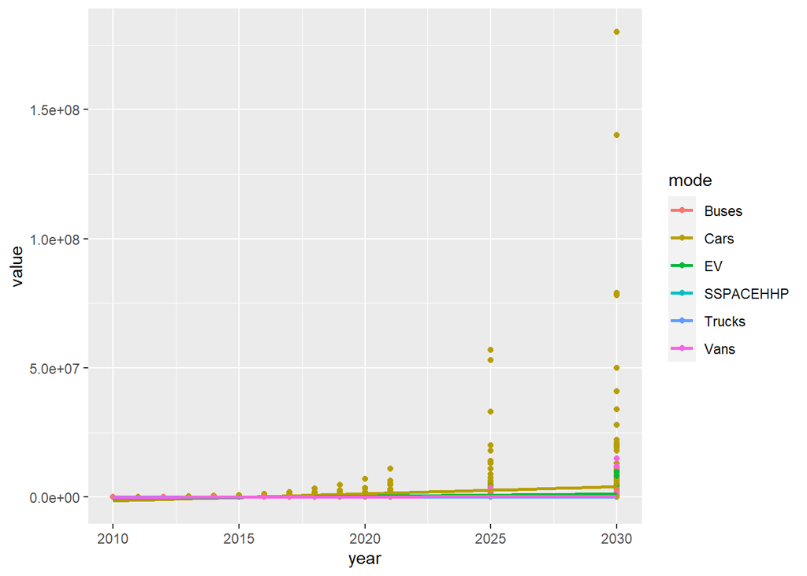

```r
# Create scatterplot
ggplot(data = data, aes(x = year, y = value, color = mode)) +
  geom_point() +
  geom_smooth(method = "lm", se = FALSE)
```

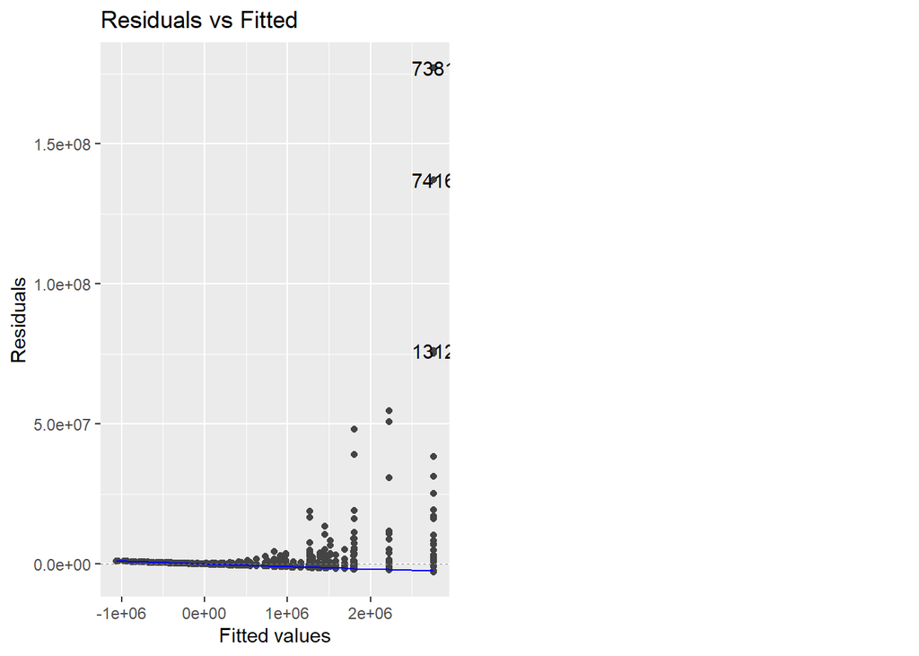

```r
# Load ggfortify package
library(ggfortify)

# Plot residuals
autoplot(model, which = 1)
```

```r
# fit linear model
model <- lm(value ~ year * powertrain, data = data)

# print model summary
summary(model)
```

```
##
## Call:
## lm(formula = value ~ year * powertrain, data = data)
##
## Residuals:
##       Min        1Q    Median        3Q       Max
##  -3284950   -337050      -915       870 176714050
##
## Coefficients:
##                                          Estimate Std. Error t value Pr(>|t|)
## (Intercept)                            -456930078   28831282 -15.848  < 2e-16
## year                                       226707      14287  15.868  < 2e-16
## powertrainEV                            456543386   38191788  11.954  < 2e-16
## powertrainPHEV                          300606133   45720196   6.575 5.20e-11
## powertrainPublicly available fast       330735022  100593794   3.288 0.001014
## powertrainPublicly available slow       226937642   98275605   2.309 0.020960
## year:powertrainEV                         -226516      18926 -11.969  < 2e-16
## year:powertrainPHEV                       -149170      22646  -6.587 4.79e-11
## year:powertrainPublicly available fast    -164118      49847  -3.292 0.000998
## year:powertrainPublicly available slow    -112620      48701  -2.312 0.020779
##
## (Intercept)                            ***
## year                                   ***
## powertrainEV                           ***
## powertrainPHEV                         ***
## powertrainPublicly available fast      **
## powertrainPublicly available slow      *
## year:powertrainEV                      ***
## year:powertrainPHEV                    ***
## year:powertrainPublicly available fast ***
## year:powertrainPublicly available slow *
## ---
## Signif. codes:  0 '***' 0.001 '**' 0.01 '*' 0.05 '.' 0.1 ' ' 1
##
## Residual standard error: 3370000 on 7424 degrees of freedom
## Multiple R-squared:  0.04093,    Adjusted R-squared:  0.03977
## F-statistic: 35.21 on 9 and 7424 DF,  p-value: < 2.2e-16
```

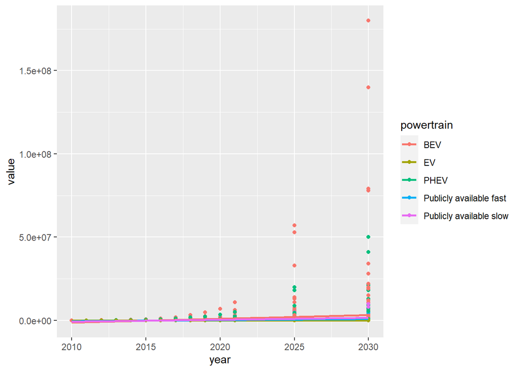

```r
# plot model predictions
ggplot(data, aes(x = year, y = value, color = powertrain)) +
  geom_point() +
  geom_smooth(method = "lm", se = FALSE, aes(group = powertrain))
```

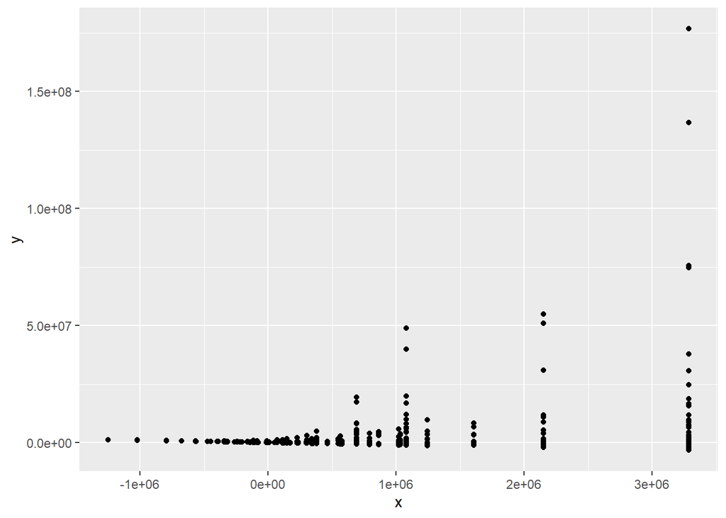

```r
# plot residuals
ggplot(data = data.frame(x = model$fitted.values, y = model$residuals)) +
  geom_point(aes(x, y))
```

```r
# fit simpler model without interaction term
simple_model <- lm(value ~ year + powertrain, data = data)

# compare model performance
anova(simple_model, model)
```

```
## Analysis of Variance Table
##
## Model 1: value ~ year + powertrain
## Model 2: value ~ year * powertrain
##   Res.Df        RSS Df  Sum of Sq     F    Pr(>F)
## 1   7428 8.5975e+16
## 2   7424 8.4329e+16  4 1.6457e+15 36.22 < 2.2e-16 ***
## ---
## Signif. codes:  0 '***' 0.001 '**' 0.01 '*' 0.05 '.' 0.1 ' ' 1
```

```r
# Summarize data by region and parameter
summary_data <- aggregate(value ~ region + parameter, data, sum)

# Rename the value column to total_energy
names(summary_data)[names(summary_data)=="value"] <- "total_energy"
```

[figure not shown]

```r
# Get world map data
world_map <- map_data("world")

# Merge map data with summarized data
map_data <- merge(world_map, summary_data, by.x = "region", by.y = "region")

# Create map plot using ggplot2
ggplot() +
  geom_map(data = map_data, map = map_data,
           aes(x = long, y = lat, map_id = region, fill = total_energy),
           color = "pink", size = 0.1) +
  scale_fill_gradient(low = "green", high = "blue") +
  theme_void()
```

[figure not shown]

```r
# Convert data to long format
data_long <- data %>%
  pivot_longer(cols = c("value"), names_to = "measurement", values_to = "measurement_value")

# Select variables for plotting
plot_data <- data_long %>%
  dplyr::select(category, parameter, measurement, measurement_value)

# Create high-dimension plot using lattice
xyplot(measurement_value ~ parameter | category * measurement, data = plot_data,
       type = c("p", "l"), auto.key = TRUE, col = c("yellow", "blue", "grey", "purple"),
       ylim = c(0, 500), xlim = c(0, 500))
```